# Lab assignment 1

## RecSys Hello World!

Code some very basic recommending algorithm from scratch and evaluate usefulness of such recommendations.

- Start with a MovieLens dataset (choose which one you prefer, ML-Latest-small already available from labs folder, others for download from https://grouplens.org/datasets/movielens/)
  - if you select larger datasets (ML-latest), apply some pre-processing to limit its size (e.g. only movies from last few years)
- Expand the dataset with a new user (you) and your preference on some of the movies (at least 5-10)
- Implement some variant of user-based or item-based KNN
  - **Describe in comments, what exactly you did: what similarity metric, what aggregation, any pre-processing, any specialties?**
- Use the system to recommend to you.
  - **Self-evaluate the recommendations. Did you like the recommendations? If not, why not?**

### Assignment completion

- Option 1: Finalize during the labs, let the teacher check your code and give you the credits.
- Option 2: Send the solution via e-mail. Your solution should be evaluated top-down (i.e., output of all cells visible). Do not forget to provide comments / assesments wherever asked to do so. **Deadline: sunday before the next labs**

# Pre-processing

### Load dataset

- using Pandas to load the MovieLens-latest dataset.
- make some basic stats to simplify you finding relevant movies

```python
import numpy as np
import pandas as pd
```

```python
#moviesDF: information about movies (pandas DataFrame)
#df: ratings in UID - OID - rating - timestamp format (pandas DataFrame)

moviesDF = pd.read_csv("movies.csv", sep=",")
moviesDF.movieId = moviesDF.movieId.astype(int)
moviesDF.set_index("movieId", inplace=True)

df = pd.read_csv("ratings.csv", sep=",")
df.columns=["UID","OID","rating","timestamp"]

ratingCounts = df.groupby("OID")["UID"].count()
moviesDF["RatingCount"] = ratingCounts
moviesDF["year"] = moviesDF.title.str.extract(r'\(([0-9]+)\)')
moviesDF["year"] = moviesDF.year.astype("float")
moviesDF.fillna(0, inplace=True)

#use this or similar conditions to find movies you can rate.
moviesDF.loc[moviesDF.RatingCount >= 10].sort_values(["year","RatingCount"], ascending=False)
```

| movieId | title | genres | RatingCount | year |
| --- | --- | --- | --- | --- |
| 122912 | Avengers: Infinity War - Part I (2018) | Action\|Adventure\|Sci-Fi | 13.0 | 2018.0 |
| 187593 | Deadpool 2 (2018) | Action\|Comedy\|Sci-Fi | 12.0 | 2018.0 |
| 122918 | Guardians of the Galaxy 2 (2017) | Action\|Adventure\|Sci-Fi | 27.0 | 2017.0 |
| 168252 | Logan (2017) | Action\|Sci-Fi | 25.0 | 2017.0 |
| 122916 | Thor: Ragnarok (2017) | Action\|Adventure\|Sci-Fi | 20.0 | 2017.0 |
| ... | ... | ... | ... | ... |
| 1927 | All Quiet on the Western Front (1930) | Action\|Drama\|War | 10.0 | 1930.0 |
| 2010 | Metropolis (1927) | Drama\|Sci-Fi | 21.0 | 1927.0 |
| 3742 | Battleship Potemkin (1925) | Drama\|War | 10.0 | 1925.0 |
| 1348 | Nosferatu (Nosferatu, eine Symphonie des Graue... | Horror | 16.0 | 1922.0 |
| 69757 | (500) Days of Summer (2009) | Comedy\|Drama\|Romance | 42.0 | 500.0 |

2269 rows × 4 columns

```python
#you can also try to search for particular movie
moviesDF.loc[moviesDF.title.str.contains("Deadpool")]
```

| movieId | title | genres | RatingCount | year |
| --- | --- | --- | --- | --- |
| 122904 | Deadpool (2016) | Action\|Adventure\|Comedy\|Sci-Fi | 54.0 | 2016.0 |
| 187593 | Deadpool 2 (2018) | Action\|Comedy\|Sci-Fi | 12.0 | 2018.0 |

```python
# update this with your real ratings (note that OID = movieId from the moviesDF)
myRatings = {
    "UID":[611,611,611,611,611,611],
    "OID":[122912,187593,122918,122916,122906,122922],
    "rating":[5.0,4.0,4.0,3.5,4.0,4.5],
    "timestamp":[0,0,0,0,0,0]
            }
```

```python
#append your ratings to the dataFrame df.
df = pd.concat([df,pd.DataFrame(myRatings)], ignore_index=True)

#add movieTitles to the df (for clarity)
movieTitles = moviesDF.title.loc[df.OID]
df["movieTitle"] = movieTitles.values
#display the ratings dataframe. Note the new values in the last rows
#df
```

### Auxiliary methods

depending on which variant of KNN you chose, the functions below might be useful for you

- jaccard similarity is probably the simplest reasonable measure of similarity between users or items
  - Check https://docs.scipy.org/doc/scipy-0.14.0/reference/generated/scipy.stats.pearsonr.html for Pearsons correlation
  - Check https://scikit-learn.org/stable/modules/generated/sklearn.metrics.pairwise.cosine_similarity.html for Cosine sim
- if you use scikit-learn for similarity, its output is a numpy array, which is considers continuous zero-based indexes
  - Note that in many datasets (MovieLens included), there are gaps in user and item IDs. Therefore, you may need to transform UIDs/OIDs to their continuous zero-based variants

```python
# Calculate jaccard similarity between two **sets** of IDs (users or items)
def jaccard_sim(a,b):
    return len(a.intersection(b))/len(a.union(b))
```

```python
# for each user, get a set of all rated items
def get_itemsets(df):
    itemsets = df.groupby("UID").agg({
        "OID": lambda x: set(x)
    }).reset_index()
    return itemsets

#for each item, get a set of all users who rated this item
def get_usersets(df):
    usersets = df.groupby("OID").agg({
        "UID": lambda x: set(x)
    })
    return usersets
```

### Your code goes here

```python
#return list of OIDs (with the size = top_k) ordered from the most relevant item
def predict(currUser, dataTrain, top_k):
    itemsets = get_itemsets(dataTrain)                  # získanie filmov pre každého užívateľa
    me = itemsets[itemsets['UID'] == currUser]          # získanie currUser
    itemsets = itemsets[itemsets['UID'] != currUser]    # odstránenie currUser

    similar_users = []
    currUserMovies = me['OID']                          # získanie mojich filmov
    for itemset in itemsets.iterrows():
        jaccard_sim_result = jaccard_sim(itemset[1]['OID'], currUserMovies.item())    # spočítanie podobnosti pomocou Jaccarda
        if jaccard_sim_result > 0:                                                    # vyberám ľudí, ktorí sú nejak podobní
            similar_users.append(itemset[1]['UID'])

    if len(similar_users) > 20:                         # vyberiem max top 20 pobobných užívateľov
        similar_users = similar_users[:20]

    filtered = dataTrain[dataTrain['UID'].isin(similar_users)]      # získam riadky dataframeu, ktoré obsahujú
                                                                    # podobných užívateľov, ich pozreté filmy a hodnotenia

    # pre každý film spočítam súčet ratingov, ktoré dostal od podobných užívateľov, zoradím podľa súčtu hodnotení zostupne (most relevant)
    result = filtered.groupby('OID').agg({'rating': 'sum'}).sort_values(by='rating', ascending=False)

    result = result.drop(currUserMovies.item()) # odstránim videné filmy

    return result.index[:top_k].tolist() # vrátim top_k filmov
```

### Display recommendations given to yourself:

```python
recommended_oids = predict(611, df, 20)
moviesDF.loc[recommended_oids]
```

| movieId | title | genres | RatingCount | year |
| --- | --- | --- | --- | --- |
| 2571 | Matrix, The (1999) | Action\|Sci-Fi\|Thriller | 278.0 | 1999.0 |
| 79132 | Inception (2010) | Action\|Crime\|Drama\|Mystery\|Sci-Fi\|Thriller\|IMAX | 143.0 | 2010.0 |
| 58559 | Dark Knight, The (2008) | Action\|Crime\|Drama\|IMAX | 149.0 | 2008.0 |
| 122904 | Deadpool (2016) | Action\|Adventure\|Comedy\|Sci-Fi | 54.0 | 2016.0 |
| 356 | Forrest Gump (1994) | Comedy\|Drama\|Romance\|War | 329.0 | 1994.0 |
| 318 | Shawshank Redemption, The (1994) | Crime\|Drama | 317.0 | 1994.0 |
| 60069 | WALL·E (2008) | Adventure\|Animation\|Children\|Romance\|Sci-Fi | 104.0 | 2008.0 |
| 59315 | Iron Man (2008) | Action\|Adventure\|Sci-Fi | 94.0 | 2008.0 |
| 2959 | Fight Club (1999) | Action\|Crime\|Drama\|Thriller | 218.0 | 1999.0 |
| 109487 | Interstellar (2014) | Sci-Fi\|IMAX | 73.0 | 2014.0 |
| 8961 | Incredibles, The (2004) | Action\|Adventure\|Animation\|Children\|Comedy | 125.0 | 2004.0 |
| 68954 | Up (2009) | Adventure\|Animation\|Children\|Drama | 105.0 | 2009.0 |
| 260 | Star Wars: Episode IV - A New Hope (1977) | Action\|Adventure\|Sci-Fi | 251.0 | 1977.0 |
| 1198 | Raiders of the Lost Ark (Indiana Jones and the... | Action\|Adventure | 200.0 | 1981.0 |
| 1210 | Star Wars: Episode VI - Return of the Jedi (1983) | Action\|Adventure\|Sci-Fi | 196.0 | 1983.0 |
| 116797 | The Imitation Game (2014) | Drama\|Thriller\|War | 50.0 | 2014.0 |
| 112852 | Guardians of the Galaxy (2014) | Action\|Adventure\|Sci-Fi | 59.0 | 2014.0 |
| 3147 | Green Mile, The (1999) | Crime\|Drama | 111.0 | 1999.0 |
| 99114 | Django Unchained (2012) | Action\|Drama\|Western | 71.0 | 2012.0 |
| 4995 | Beautiful Mind, A (2001) | Drama\|Romance | 123.0 | 2001.0 |

- were the recommendations relevant? Celkom áno
- were they surprising? Niektoré... Shawshank, Green Mile, Forrest Gump
- how many movies you know from before? 20/20
- how many would you consider to watch? Kľudne všetky.
- did you like the recommendations overall? Áno, väčšina sú akčné, sci-fi, čo mi vyhovuje.

# Additional content

### Basic analysis of MovieLens dataset

```python
from matplotlib import pyplot as plt
%matplotlib inline
```

```python
df["rating_int"] = df.rating.astype(int)
```

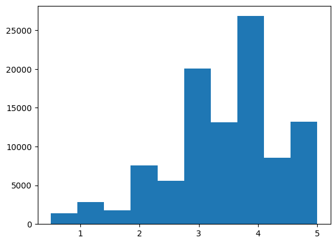

```python
plt.hist(df.rating,10)
```

```python
df["timestamp_float"] = df.timestamp.astype(np.float32)
```

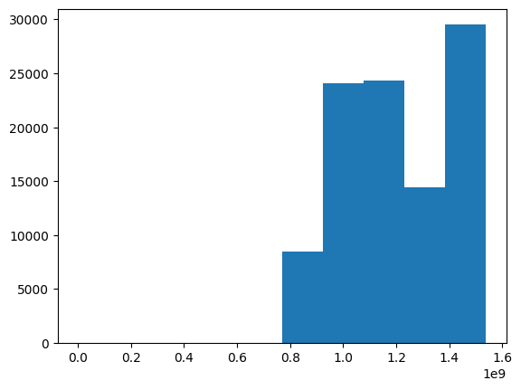

```python
plt.hist(df.timestamp_float,10)
```

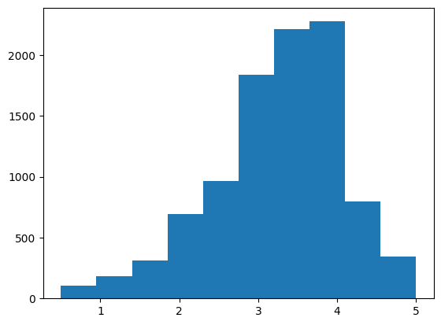

```python
plt.hist(df.groupby(df.OID)["rating"].agg("mean"))
```

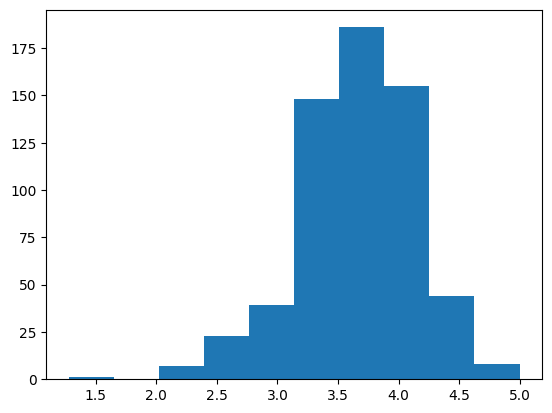

```python
plt.hist(df.groupby(df.UID)["rating"].agg("mean"))
```

```python
moviesDF.year.dtype
```

```
dtype('float64')
```

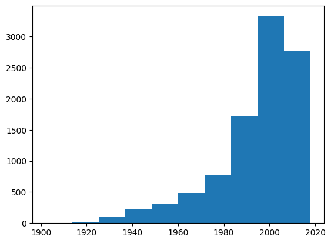

```python
plt.hist(moviesDF.loc[moviesDF.year > 1900].year)
```